# Project2-HypothesisTesting

## Problem Statement

Par Inc., is a major manufacturer of golf equipment. Management believes that Par’s market share could be increased with the introduction of a cut-resistant, longer-lasting golf ball. Therefore, the research group at Par has been investigating a new golf ball coating designed to resist cuts and provide a more durable ball. The tests with the coating have been promising.

One of the researchers voiced concern about the effect of the new coating on driving distances. Par would like the new cut resistant ball to offer driving distances comparable to those of the current-model golf ball. To compare the driving distances for the two balls, 40 balls of both the new and current models were subjected to distance tests.

The testing was performed with a mechanical hitting machine so that any difference between the mean distances for the two models could be attributed to a difference in the design. The results of the tests, with distances measured to the nearest yard, are contained in the data set “Golf”.

```r
# Loading the library and read the csv

Par_Inc <- read.csv('Par-Inc.csv')
```

## Summary of the data

```r
summary(Par_Inc)
```

```
##     Current           New
##  Min.   :255.0   Min.   :250.0
##  1st Qu.:263.0   1st Qu.:262.0
##  Median :270.0   Median :265.0
##  Mean   :270.3   Mean   :267.5
##  3rd Qu.:275.2   3rd Qu.:274.5
##  Max.   :289.0   Max.   :289.0
```

```r
# Attaching the dataset for easy accessing of variables
attach(Par_Inc)
```

## Plotting old and New distributions

For understanding the spread of the data points, it’s always intuitive to plot

### Distribution of current observations

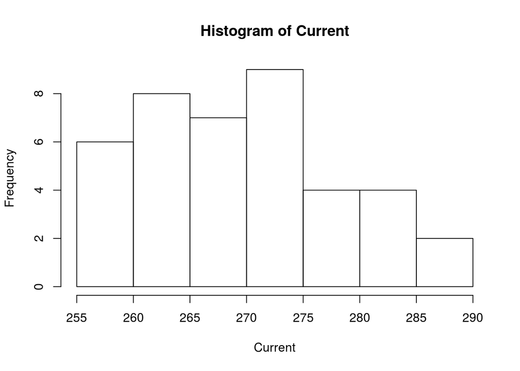

```r
hist(Current)
```

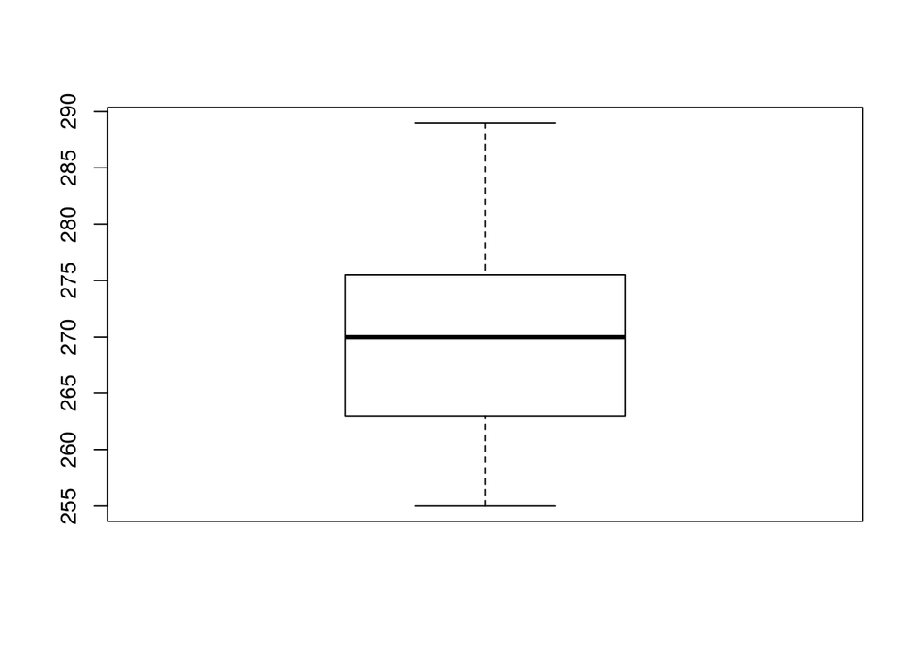

```r
boxplot(Current)
```

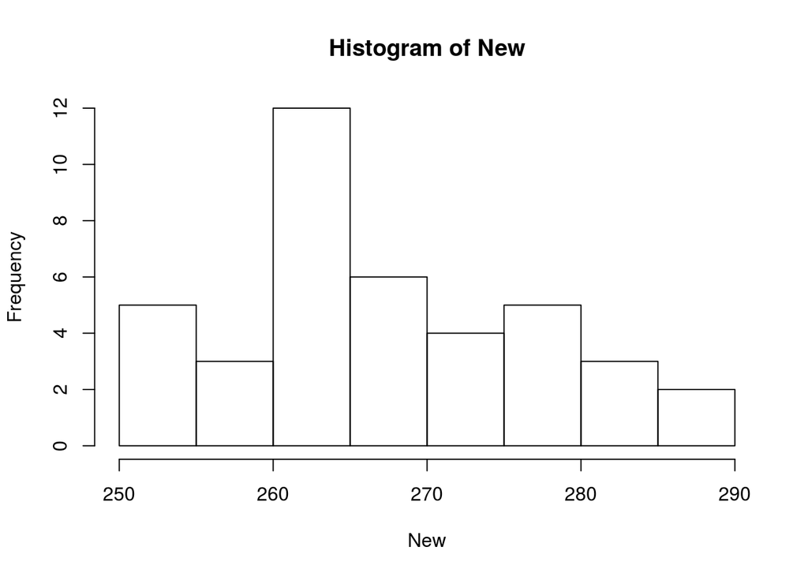

```r
hist(New)
```

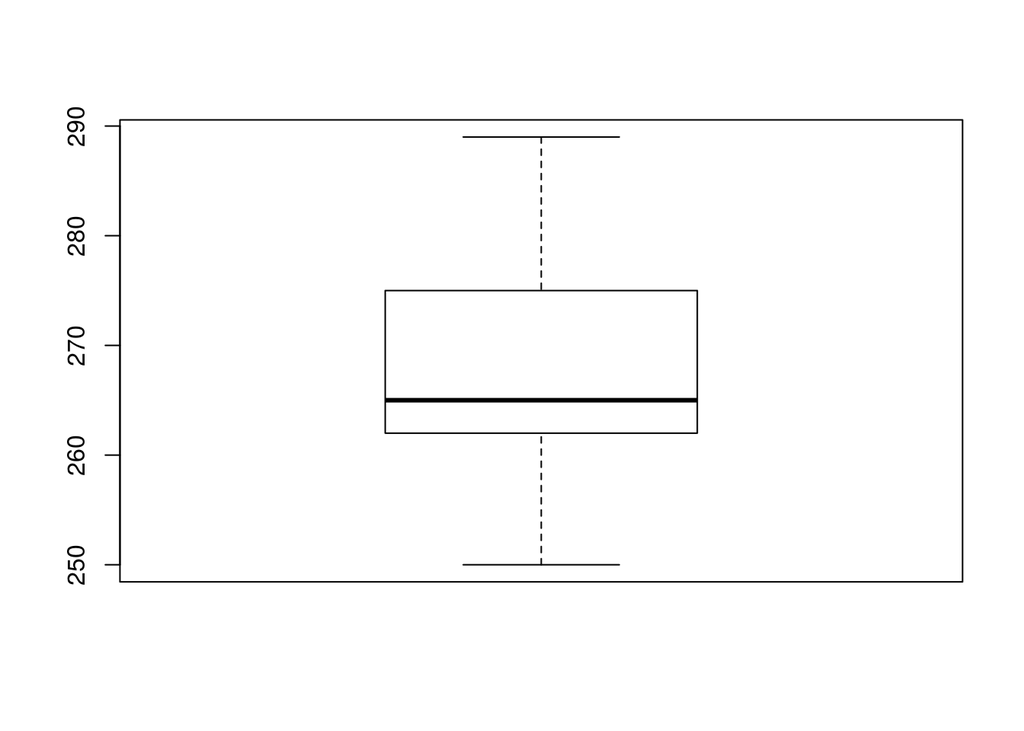

```r
boxplot(New)
```

## Observations from plots

1. Looking at the plots, both Current and new observations seem to be normally distributed. And also, both of them are skewed in similar manner.
2. The spread of both distributions are almost same.
3. The median looks little different in both.

## Setting up Hypothesis

1. The level of significance (Alpha ) = 0.05.
2. The sample size , N = 40 which is sufficiently large for a Zstat Test.
3. But since the population standard deviation (Sigma) is unknown, we have to use a Tstat test.
4. Degree of Freedom: Since the sample is the same for both Sampling tests, we have N-1 degrees of freedom : 39
5. As the hypothesis is that the new ball would different in distances to the old ball, we would prefer a Two tailed T test

## Formulation of Hypothesis

1. As we want to prove the hypothesis of distances not being equal Ha –> mu1< >mu2
2. H0 = mu1 = mu2

```r
# 95% confidence interval for Current distances
muCurrent <- mean(Current)
sdCurrent <- sd(Current)
n <- 40 # Number of observations
errorCurrent <- qt(0.975,df=n-1)*sdCurrent/sqrt(n)
cat('Confidence Interval for Current is ', muCurrent-errorCurrent, ' - ', muCurrent+errorCurrent)
```

```
## Confidence Interval for Current is  267.4757  -  273.0743
```

```r
# 95% confidence interval for Current distances
muNew <- mean(New)
sdNew <- sd(New)
errorNew <- qt(0.975,df=n-1)*sdNew/sqrt(n)
cat('Confidence Interval for New is ', muNew-errorNew, ' - ', muNew+errorNew)
```

```
## Confidence Interval for New is  264.3348  -  270.6652
```

```r
# Running t test
t.test(Current, New, paired = TRUE, conf.level = 0.95, alternative = "two.sided")
```

```
##
##  Paired t-test
##
## data:  Current and New
## t = 1.277, df = 39, p-value = 0.2092
## alternative hypothesis: true difference in means is not equal to 0
## 95 percent confidence interval:
##  -1.620536  7.170536
## sample estimates:
## mean of the differences
##                   2.775
```

## Inference

Confidence Interval of difference between means is -1.620636 to 7.170536

The test statistic is within the range of confidence interval From nthe test results, the p-value = 0.2092 which is very much greater than the significance level

Hence the null hypothesis can’t be rejected.

So, it can be concluded that the distances of both Current and the New balls are similar